# Red and white wines characterization

## Principal Component Analysis

The last part of the analysis is to perform PCA on the complete dataset. Even if we just concluded that there are some outliers, the analysis is to be performed into the complete dataset. PCA shows the most important features of the dataset, including outliers, if important. Therefore, I will include them to see if we can get some additional insight. We can start by visually judging the first two PC.

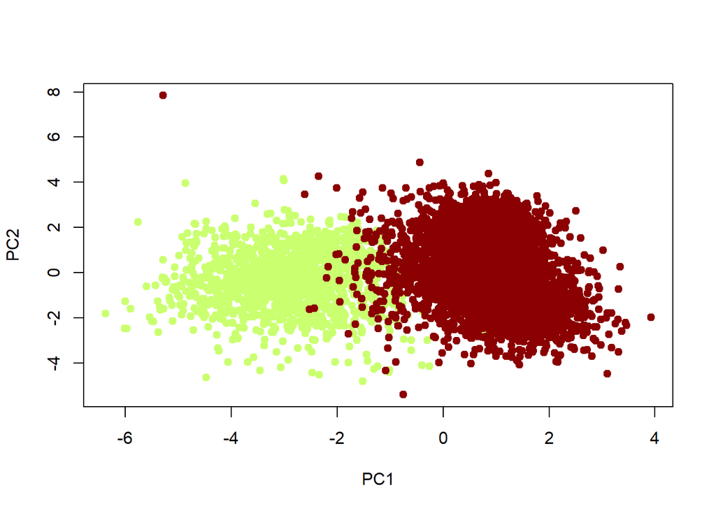

It is clearly seen that the first two PCs show the presence of the two different groups, splitted in half with an almost vertical line. This coincides with the two categories of wine: red and white, as the colors show for the same color of the wine. The presence of outliers is also evident, being easy to identify them as well.

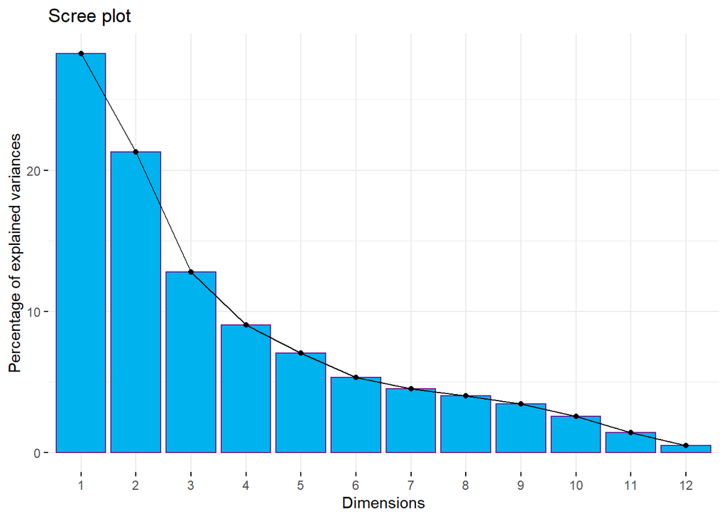

The next question we could ask ourselves is how many PCs are important. The previous plot shows the percentage of explained variance for each PC. One can see that the first two ones only account for roughly half the variance. However, as can be seen in the correlation plot between the four first PC, it is enough to unveil the distinction between the groups only with PC1 and PC2. So, in the end, the dimensionality of the problem is reduced to 4 or even 2 useful PCs that are enough to explain a great deal of the variance and distinguish between the groups.

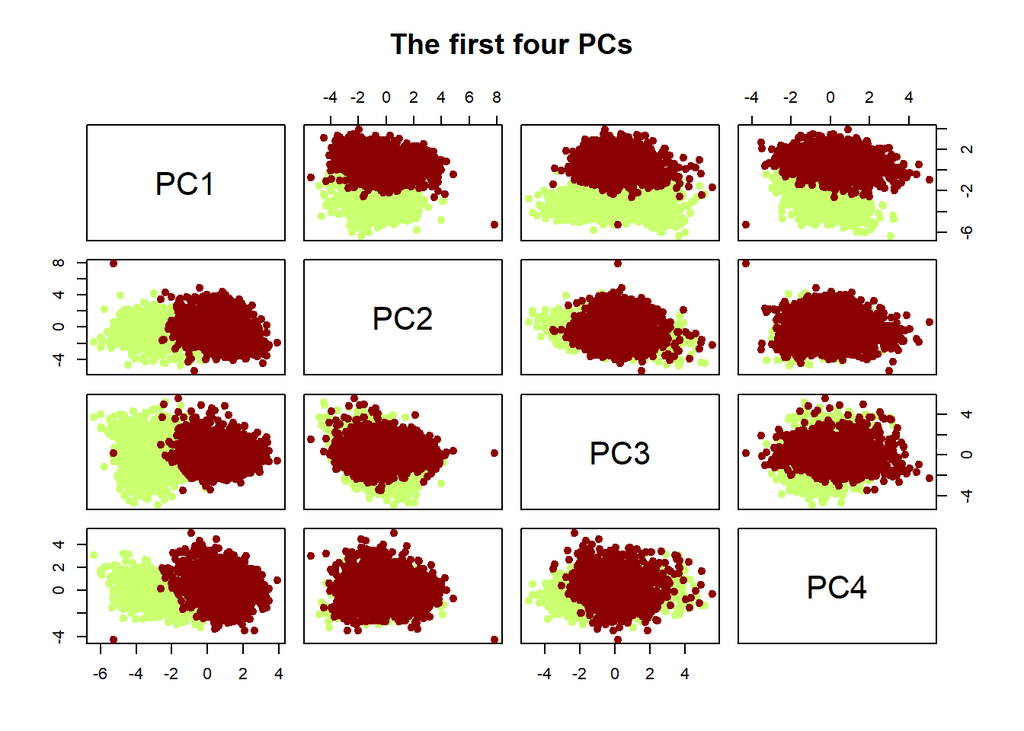

As we have just seen, principal components reduce the dimensionality of the problem. However, these original variables have some physical meaning, but how can one give an interpretation to the principal components? In order to do that one can see the different weights onto the two first principal components, that is, the variables that contribute the most to these PCs.

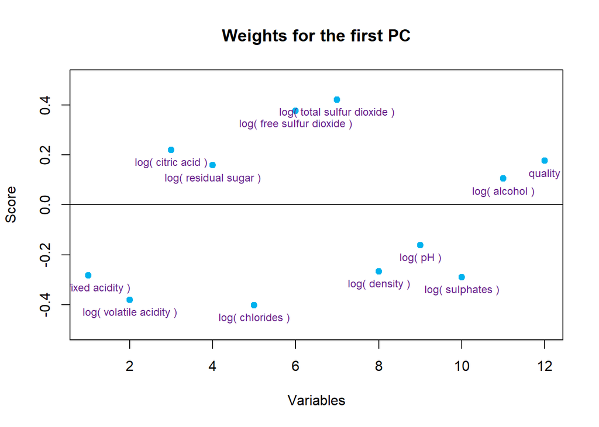

We can see that the first principal component is determined mostly by the different quantities of sulfur dioxide as well as chlorides and volatile acidity. If we look back at the kernel densities plot, we can see that these two types of wine followed distributions with little overlap, therefore it makes sense that they contribute to PC1 that is the one that separates the group.

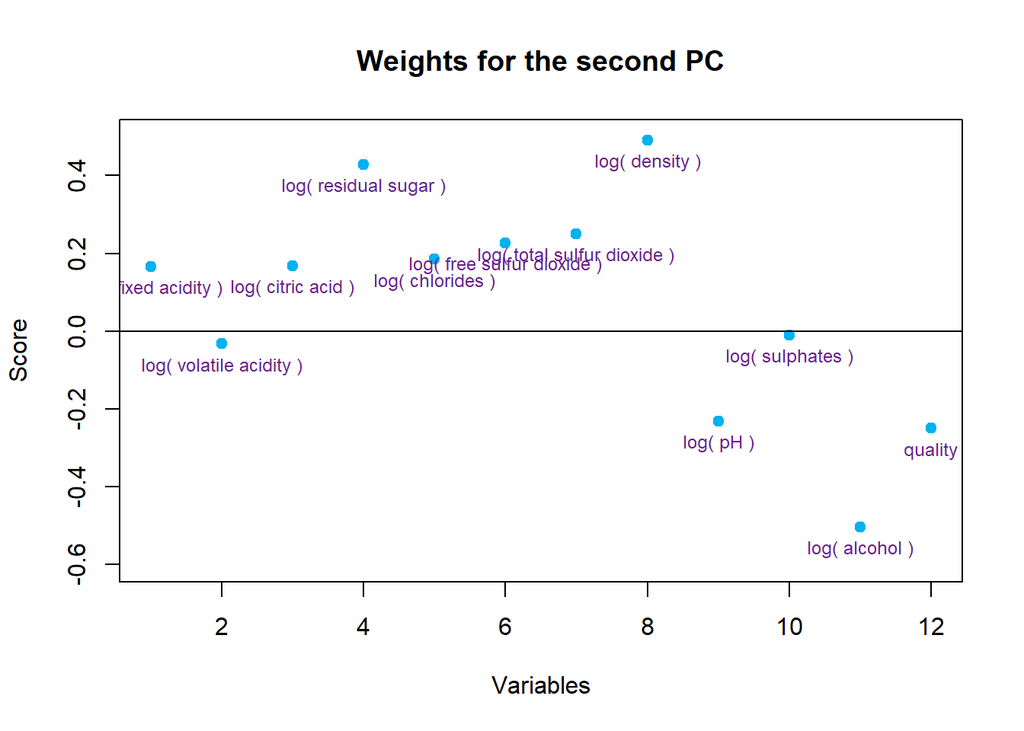

The contributions to the second principal component are mainly alcohol percentage, density and residual sugar. However, there does not seem to be an obvious group that we can create in base of this PC but we can give an interpretation to it using some general knowledge of wines. The residual sugar is the sugar that is left in the wine after the fermentation. Sugar is a key ingredient for fermentation so, in order to avoid that the wine keeps fermenting afterwards, sweet wines need a higher concentration of alcohol and acidity and sometimes need treatment with sulfur compounds. So, this PC could be related with the sweetness/strength of the wine. But the weights don’t give us the direction of the PC. We don’t know whether high values of this second PC relates to sweet wines or strong wines. The following plots help us to identify more clearly the variables that really generate extremes (groups) at each PC as well as the direction of the arrow for each variable on the PC.

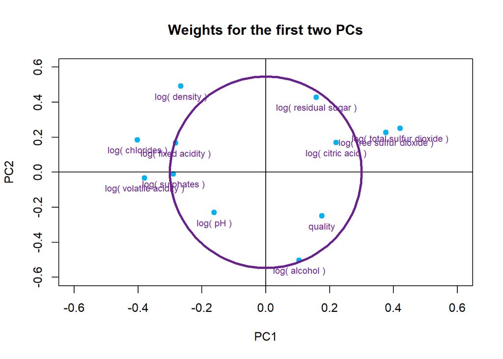

This plot shows the contributions of each variable to both PC at the same time. Points outside the circle indicate that that variable contributes greatly to both PCs, therefore being a candidate for group separation. We can see that density, acidity, chlorides and sulfur variables are the ones contributing the most. Other variables, such as the pH, citric acid, or even the quality, which a priori could seem very important, don’t make such a difference.

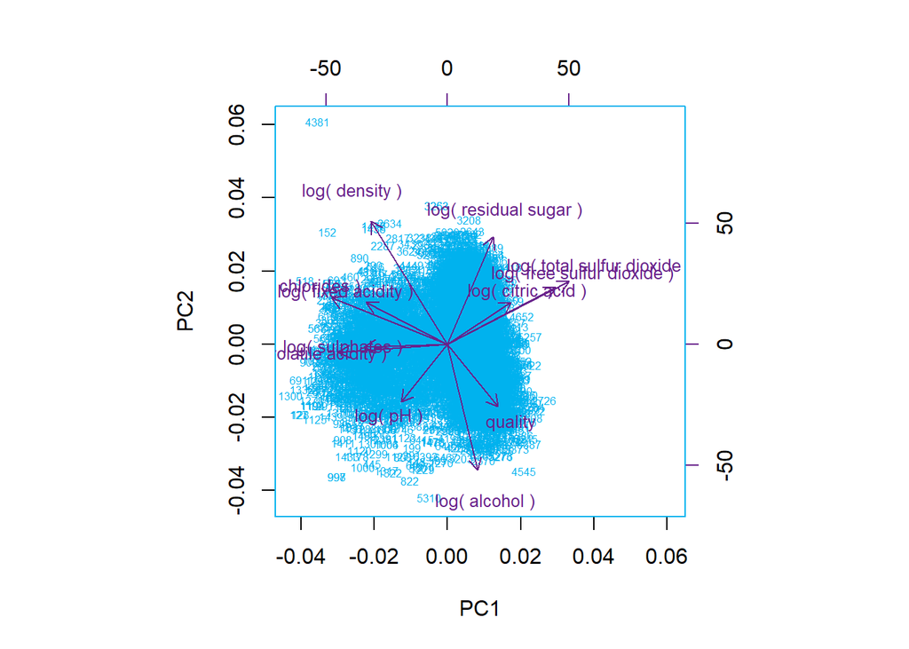

This last plot shows the direction of the arrow. We know that PC1 characterizes red or white wines. For increasing sulfur dioxide and citric acid, PC1 increases, which means we would have a red wine. For decreasing PC1, the most important variables are the acidity, chlorides and sulphates. So, high values of these magnitudes are associated with white wines. PC2 relates to the sweetness and strength of the wine. For low values of PC2 we would have an alcoholic non-sweet wine, and better, in general, because quality aims in that direction. This makes sense because if a wine it’s too acid, it won’t be good. We can check that the pH also points in the same direction, also supporting the non-acid hypothesis. On the other hand, for high values of PC2, a light sweet wine.

Finally, plotting the correlations between the original data set and the scores of the PC is useful to understand also which are the important variables in the data set in terms of variability.

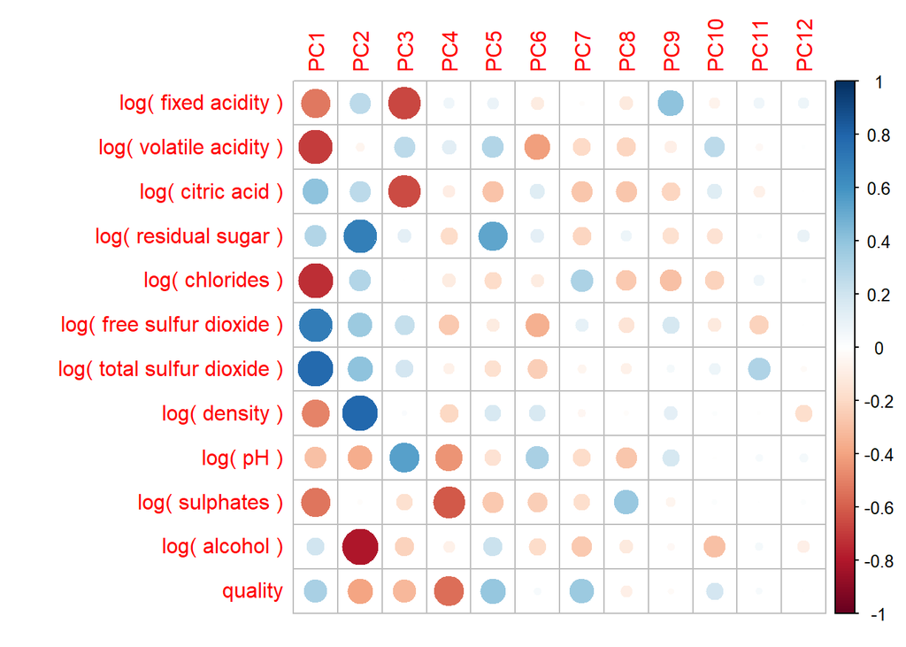

## Discussion and Conclusions

In conclusion, this study has analyzed main traits of wine, determining the mean values of the variables and the relation between them in a robust manner as well as determining the fundamental differences between red and white wines. This has been enhanced by performing Principal Component Analysis, showing that sulfur dioxide and citric acid are related with red wines while acidity, chlorides and sulfur, with white wines.

Furthermore, PCA has shown to be very effective in reducing the dimension of the problem, being able to differentiate between red and white wines just from the first principal component and between strong taste wines from the second principal component, just two dimensions, as well as providing insight on the related variables, as stated before.

However, there are some things that might be taken into account.

First, in order to apply the MCD procedure to obtain robust estimators for mean, covariance and correlation, it is necessary to work with symmetric datasets. This is a limitation of the study that was attempted to be corrected by taken logarithms, but certainly there was no perfect symmetry.

On the other hand, taking logarithms lead to undefined values for citric acid. This problem was solved and still we got good MCD estimators.

Finally, we have used that variables are normal, which the logarithms can approximate, in order to assume that Mahalanobis distances follow a chi squared so that one can detect outliers. However, even with the logs, it seems unlikely that there is complete normality. Therefore, the outlier treatment could be improved by searching for a transformation that preserves symmetry and doesn’t create this problem with citric acid, as well as checking for non normality or by using a general distribution for Mahalanobis distances that doesn’t depend on normality of the variables.